# Universidade Aberta do Brasil

Relatório parcial - Matcds

Anderson Fonseca

# Introdução

Universidade Aberta do Brasil é um programa para universalizar o ensino superior no país. Com aulas online é possível levar para um maior número de cidades e em lugares mais remotos, além de ser mais acessível para as pessoas que trabalham. Com tamanha importância é de interesse público ter algumas informações a respeito do programa, como: Quantas cidades são atendidas? Qual tipo de curso é mais oferecido? Existe diferença dos tipos de curso oferecido em cada região? Quais são os estados em que mais pessoas se formam? Qual o percentual de desistência? Entre outras questões. Para tentar responde-las utilizarei uma base de dados com 6666 observações sobre a UAB nos anos de 2017, 2018, 2019 e 2020, obtido em: https://dados.gov.br/dataset/2017-a-2020-programa-universidade-aberta-do-brasil-uab1

Segundo este conjunto de dados, a UAB atendeu 853 municípios nos 26 estados e o Distrito Federal nos 4 anos citados.

# Resultados

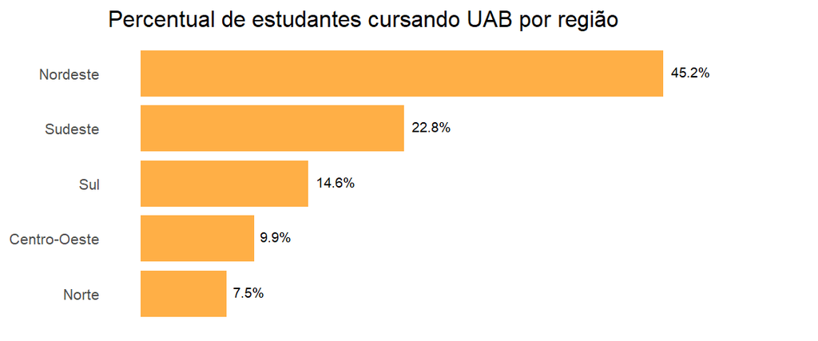

**Figura 1:** Percentual de estudantes cursando a UAB por região

A região com número de estudante é a Nordeste com praticamente o dobro da segunda maior, a Sudeste. Seguidas das regiões Sul, Centro-Oeste e Norte, estas 3 somadas tem menos estudantes na UAB que a região Nordeste.

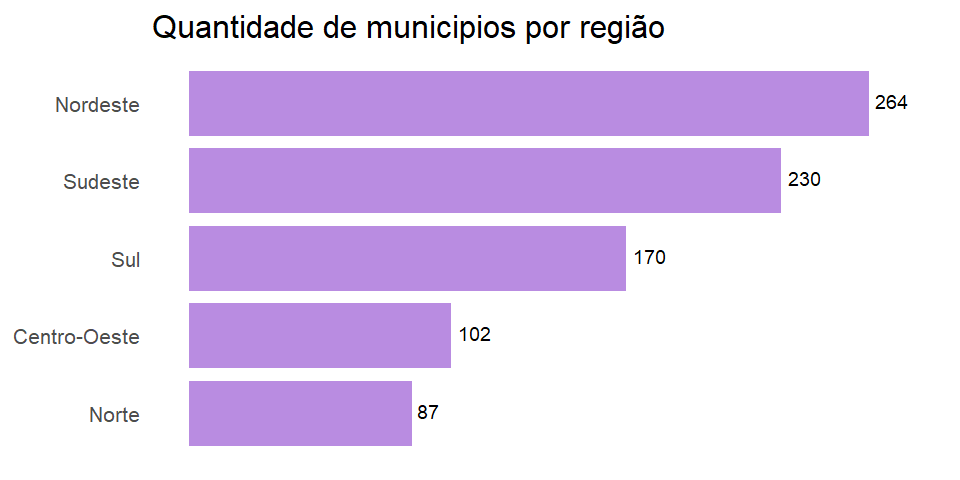

**Figura 2:** Quantidade de municipios com cursos da UAB por região

A região com maior número de municípios atendidos pela UAB é a região Nordeste, com 264, seguidos da Sudeste, Sul, Centro-oeste e Norte.

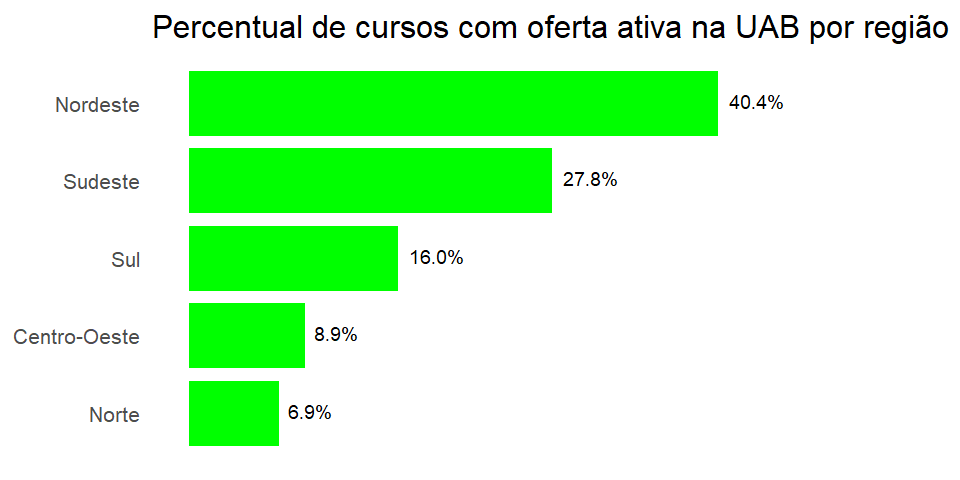

**Figura 3:** Percentual de cursos com oferta ativa na UAB por região

A região nordeste também lidera o ranking de percentual de cursos ativos, com aproximadamente 40%, mais que as regiões Sul, Centro-oeste e Norte somadas. E em segundo lugar está a região Sudeste.

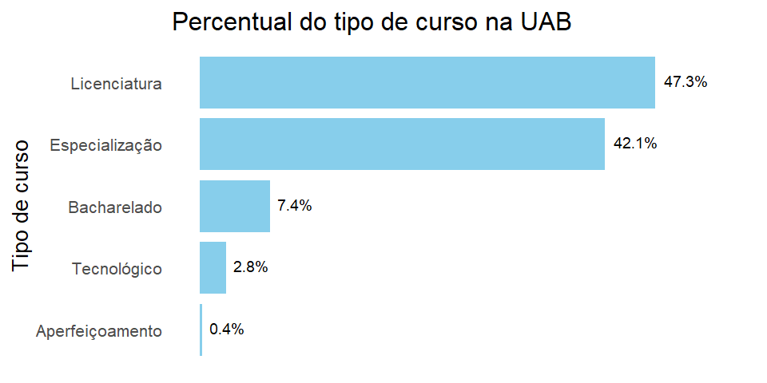

**Figura 4:** Percentual do tipo de curso na UAB

O curso mais comum é de Licenciatura com a aproximadamente 47%, seguido de Especialização com 42%, portanto 89% dos cursos da UAB são de Licenciatura ou Especialização. Os menos cursados são os cursos de Aperfeiçoamento.

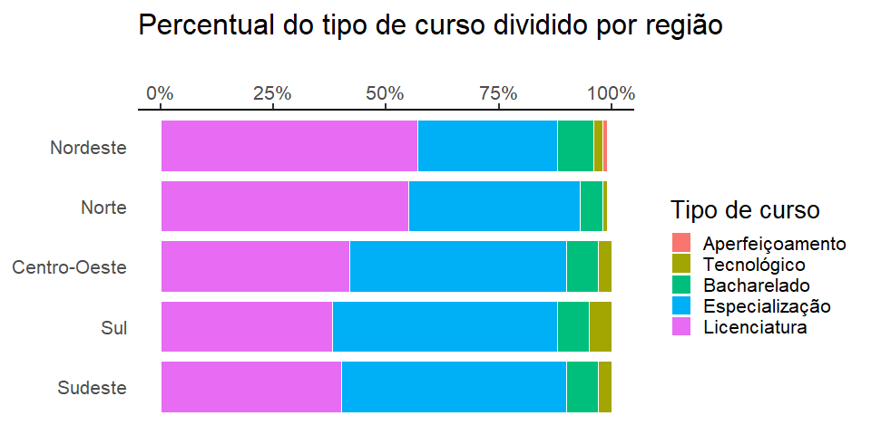

**Figura 5:** Percentual do tipo de curso dividido por região

Na Figura 5 é possível observar que os tipos de cursos apresentam frequências diferentes a depender da região. Nas regiões Norte e Nordeste os cursos de licenciaturas são os predominantes, enquanto nas demais regiões são os cursos de especialização. Os cursos de aperfeçoamento só teve na região Nordeste.

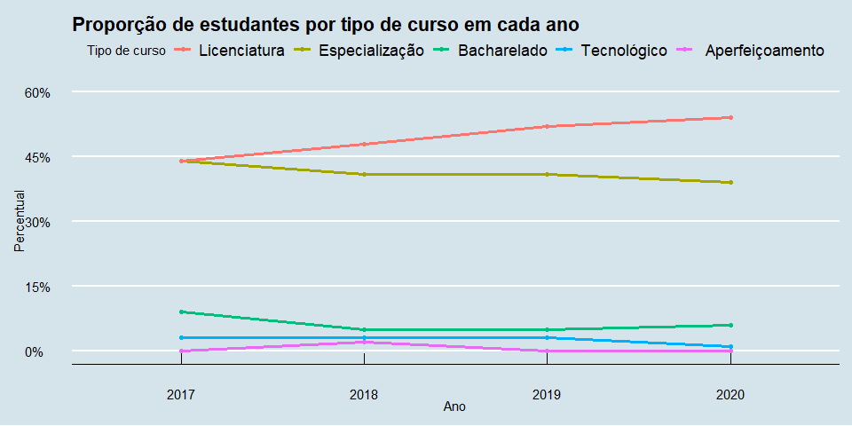

**Figura 6:** Proporção de estudantes por tipo de curso em cada ano

Os cursos de Licenciatura e Especialização tinham o mesmo percentual de estudantes em 2017 (44%), mas os percentual de estudantes nos cursos de licenciatura aumentaram enquanto os de especialição reduziram, tendo a maior diferença em 2020, com 54% e 39%.

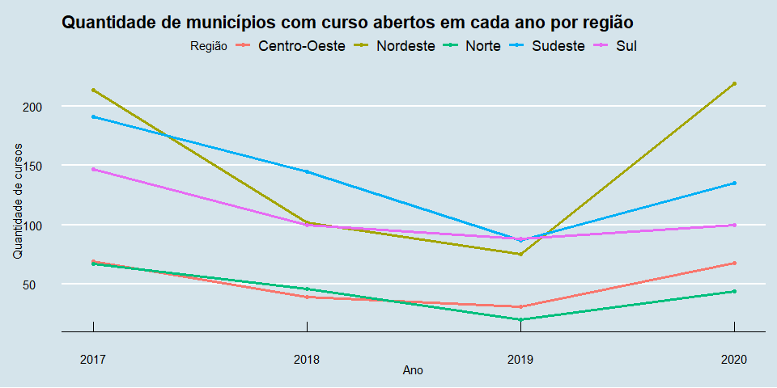

**Figura 7:** Quantidade de municípios com curso abertos em cada ano por região

Houve uma queda no número de municípios ofertando novos cursos em 2018 e 2019, mas em 2020 voltou a um patamar próximo ao de 2017. A região Nordeste perdeu o primeiro lugar em 2018 mas retornou em 2020.

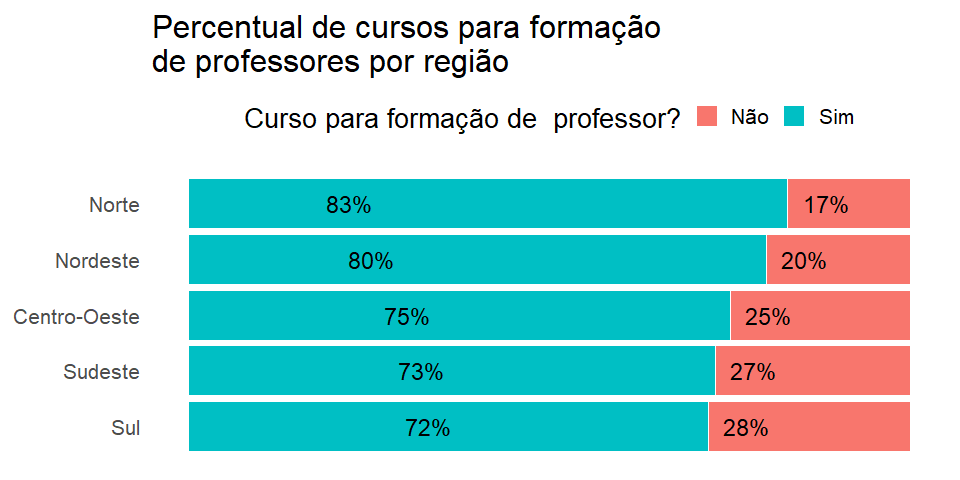

**Figura 8:** Percentual de cursos para formação de professores por região

Os cursos para formação de professores são maiorias em todas as regiões. A região Norte lidera o ranking, com 83% dos cursos da região sendo para formar professores. Enquanto na região Sul esse percentual é de 72%. Mostrando uma diferença entre as regiões.

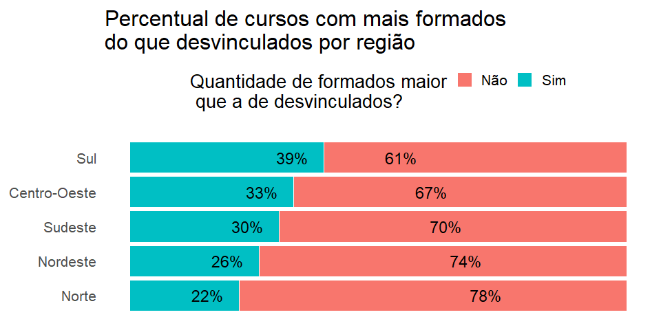

**Figura 9:** Percentual de cursos com mais formados do que desvinculados por região

Em 39% dos cursos da região Sul teve mais estudantes se formados do que desvinculados (desistência oficial do curso), esse é o maior percentual, seguido da região Centro-Oeste com 33%, em último lugar aparece a região Norte com 22%. Mais uma evidência da discrepância entre as regiões.

# Conclusão

A Universidade Aberta do Brasil tem papel fundamental na sociedade brasileira, tornando mais fácil atingir o nível superior. E este relatório trouxe a luz algumas informações importantes a respeito do programa, explorando as diferenças entre as regiões e deixa como trabalho futuro a construção de um *dashboard* com os principais gráficos e presença de mapas interativos para visualizar o comportamento de algumas variáveis de acordo com as unidades federativas da união.